# Course Project: Reproducible Research

## Panel plot comparing the average number of steps taken per 5-minute interval across weekdays and weekends

Adding another column ‘day’ to data representing the weekday at the corresponding date.

```r
df$day <- weekdays(df$date)
```

Creating a vector ‘weekday’ containing all days of week that comes under category of weekday.

```r
weekday <- c("Monday", "Tuesday", "Wednesday", "Thursday", "Friday")
```

Modifying the column ‘day’ by values in it. If the value in it represents weekday, it will be modified to weekday and if value represents weekends it will be modified to weekend. Also, modifying the data type of all whole column from character to factor.

```r
df$day <- ifelse(df$day %in% weekday, "weekday", "weekend")
df$day <- as.factor(df$day)
```

The column ‘day’ is a factor now with two levels. It can be seen using the str function.

```r
str(df)
```

```
## 'data.frame':    17568 obs. of  4 variables:
##  $ steps   : num  37.4 37.4 37.4 37.4 37.4 ...
##  $ date    : Date, format: "2012-10-01" "2012-10-01" "2012-10-01" ...
##  $ interval: int  0 5 10 15 20 25 30 35 40 45 ...
##  $ day     : Factor w/ 2 levels "weekday","weekend": 1 1 1 1 1 1 1 1 1 1 ...
```

Subsetting the dataset to dataset only containing average steps taken each interval grouped by day, the corresponding interval, and day and storing it in a variable ‘stepseachintervalbyday’

```r
stepseachintervalbyday <- aggregate(steps ~ interval + day, df, mean)
```

Making a panel plot containing the time series plot of average number of steps taken vs 5-minute interval using ggplot function and saving the plot in png file, “plot4.png”.

```r
png("plot4.png")

plot4 <- ggplot(stepseachintervalbyday, aes(interval, steps)) +geom_line() +                      facet_grid(day ~ .) + xlab("Interval") + ylab("Number of Steps")

print(plot4)

dev.off()
```

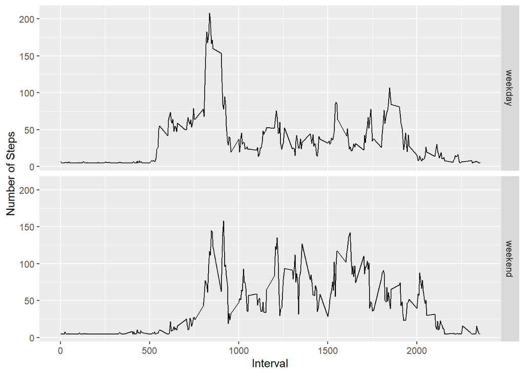

```r
print(plot4)
```

## All of the R code needed to reproduce the results (numbers, plots, etc.) in the report

All plots that are created are also uploaded along with this file.